# Strategie rozwiązywania zadań - PISA2015

Wioleta Stojak, Szymon Majewski

8 stycznia 2017

# Wstęp

OECD (Organizacja Współpracy Gospodarczej i Rozwoju) od 2000 roku bada poziom światowego szkolnictwa, oceniając nie stan wiedzy uczniów, ale umiejętności posługiwania się nią - na tym właśnie opiera się badania PISA (Programme for International Student Assesment). To ono sprawdza 15-latków z całego świata pod kątem ich zdolności do rozwiązywania problemów, analizowania, argumentowania i interpretowania. Bada umiejętność myślenia i przygotowanie do dorosłego życia. I tak np. gdy w ramach badania PISA oceniane jest “czytanie”, uczniowie dostają teksty, z którymi mogą spotkać się w codziennym życiu np. fragmenty instrukcji obsługi, czy artykułów prasowych. Celem projektu jest znalezienie strategii, którą mogli obrać uczniowie w trakcie rozwiązywania testu. Niektórzy uczniowie mogą poświęcić więcej czasu na początku testu, inni pod jego koniec.

# Dane

Każdy wiersz dostępnych danych opisuje czas rozwiązywania jednego zadania.

- Kraj z którego pochodzi uczeń
- Szkoła do której chodzi uczeń
- Student, czyli ID ucznia w danej szkole w danym kraju
- Zestaw – numer zestawu zadań, które student rozwiązywał
- Czas – w tysięcznych sekundy
- Zadanie – identyfikator zadania, które jest rozwiązywane
- Pozycja – informacja w której części całego testu wystąpiło to zadanie. Cały dwugodzinny test jest podzielony na 4 mniej więcej równe części, a ta kolumna opisuje kod określonej części
- Obszar – określa czy zadanie dotyczy czytania czy matematyki.

```r
load("C:/Users/Wioleta/Downloads/onlyTimingsLong.rda")
head(onlyTimingsLong)
```

```
##            Kraj  Szkola Student Zestaw    Czas Zadanie Pozycja Obszar
## 10737 Australia 3600001 3601769     31  195552 R219Q01       3      R
## 10742 Australia 3600001 3605983     85  143354 R219Q01       2      R
## 10747 Australia 3600001 3602143     36  206815 R219Q01       4      R
## 10759 Australia 3600002 3611016     37  117352 R219Q01       1      R
## 10787 Australia 3600003 3605314     36  174955 R219Q01       4      R
## 10794 Australia 3600003 3611875     41 1269775 R219Q01       2      R
```

Wykorzystane pakiety:

```r
library(MASS)
library(cluster)
library(ggplot2)
library(factoextra)
library(ggfortify)
library(dendextend)
library(stats)
library(scales)
library(plotly)
library(flexclust)
library(gridExtra)
library(reshape2)
```

## Obróbka danych

# Statystyki dla szkół

Dla każdej ze szkoły stworzyliśmy następujące statystyki:

- średnia czasu rozwiazywania zadania przez studentów z każdej pozycji testu, z podziałem na matematykę i czytanie, oraz z podziałem na obszar i pozycje, które zostały podzielone przez odpowiednia sumę średnich z poszczególnych części tak aby obrazować proporcje
- średnie odchylenie standardowe czasu rozwiązywania zadania przez studenta z podziałem na matematykę i czytanie
- średni maksymalny czas rozwiązywania zadania przez studenta z podziałem na matematykę i czytanie
- średnie odchylenia czasu rozwiązywania zadań przez studenta dla każdej pozycji
- średni łaczny czas rozwiązywania zadań z podziałem na matematykę i czytanie
- średnie kwantyle rzędu 0.25 i 0.75 czasu rozwiązywania zadania przez studenta z podziałem na matematykę i czytanie
- średnia skośność czasu rozwiązywania zadań przez studenta

# Wstępna analiza danych

Poniżej zamieszony jest wykres średniego czasu rozwiązywania zadań, oraz średni czas z matematyki i czytania z każdego wybranego kraju. Widzimy, że Korea charakteryzuje się najkrótszym średnim czasem rozwiazywania zadań, natomiast Peru wypada najgorzej na tle innych krajów. Możemy zauważyć, że dla każdego kraju mamy następującą zależność: średni czas z matematyki jest zawsze większy od ogólnej średniej, a średni czas rozwiązywania zadań z czytania jest mniejszy od ogólnej średniej.

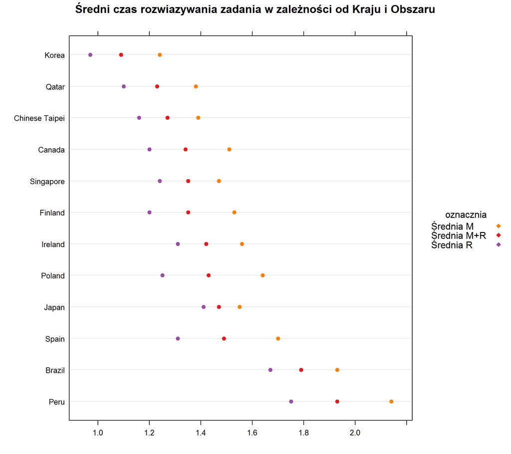

Poniższy wykres obrazuje średnie czasy rozwiązywania zadań w poszczególnych częściach testu w zależności od kraju. Aby wykres był czytelniejszy wartości średnich zostały uporządkowane malejąco w zależności od pozycji 1. Analizując wynik możemy przedstawić pewną hipotezę na temat strategii rozwiązywania zadań. Widzimy, że pierwsza część testu charakteryzuje się największą średnia czasu, natomiast patrząc na 4 została ona rozwiązana najszybciej. Zatem czy oznacza to, że studenci na początku testu będąc skupieni na zadaniu i chcąc rozwiązać je najlepiej poświęcali na nie średnio więcej czasu, a na koniec pod presja czasu wybierali losowo odpowiedzi? Niekoniecznie, ponieważ patrząc na wcześniejszy wynik mogło zdarzyć się tak, że pierwszymi zadaniami były zadania z matematyki, które charakteryzują się dłuższym czasem rozwiazywania, dlatego były po prostu dla uczniów trudniejsze. Zauważmy również ze kraje takie jak Chinise Taipei, Irlandia czy Korea charakteryzują się względnie małą różnicą średnich czasów w czterech pozycjach, natomiast Katar wyróżnia się a tle innych państw najniższa średnia z ostatniej części oraz relatywnie duża z pierwszej. Może to wskazywać na istnienie grup charakteryzujących się równomiernym gospodarowaniem czasu na każda z części oraz takich którzy spędzają najmniej czasu na ostatnią część ponieważ poświęcają swoja uwagę pierwszym zadaniom.

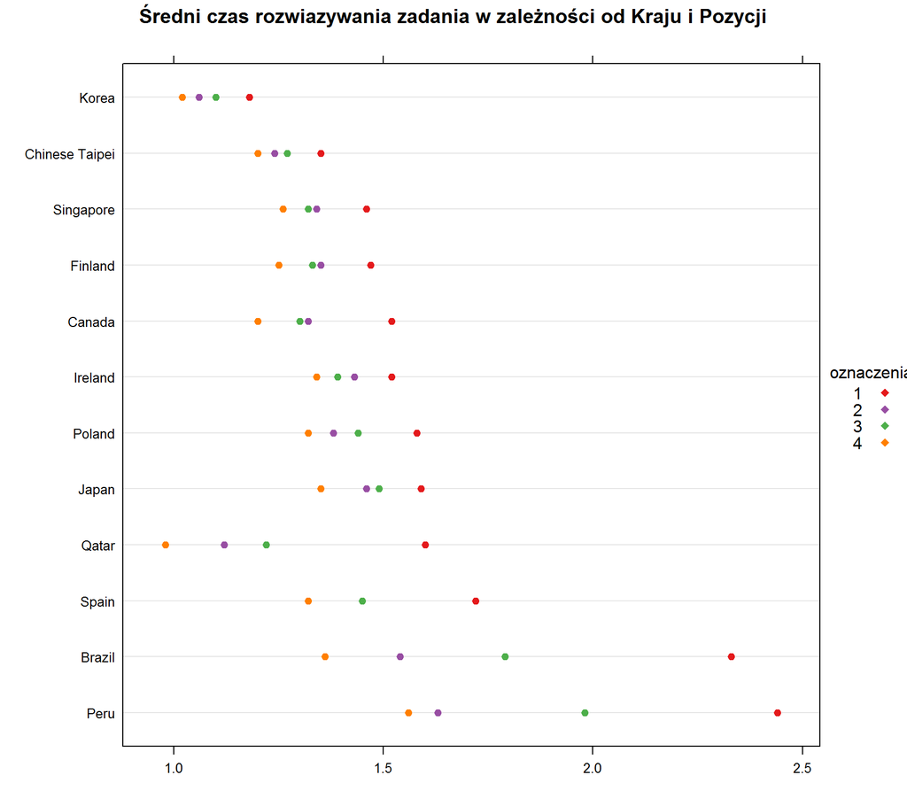

# Wybór liczby klastrów

Aby podzielić nasz zbiór na odpowiednie klastry posłużyliśmy się analizą hierarchiczną i k-means. Natomiast by znaleźć ich optymalną liczbę skorzystaliśmy z **gap statistic**.

Na poniższym wykresie widać, że “optymalna” liczba klastrów dla **analizy hierarchicznej** to 3.

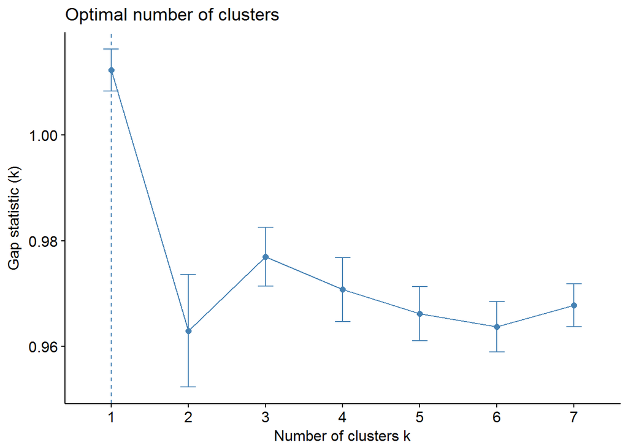

Dla **kmeans** “optymalna” liczba klastrów to 3.

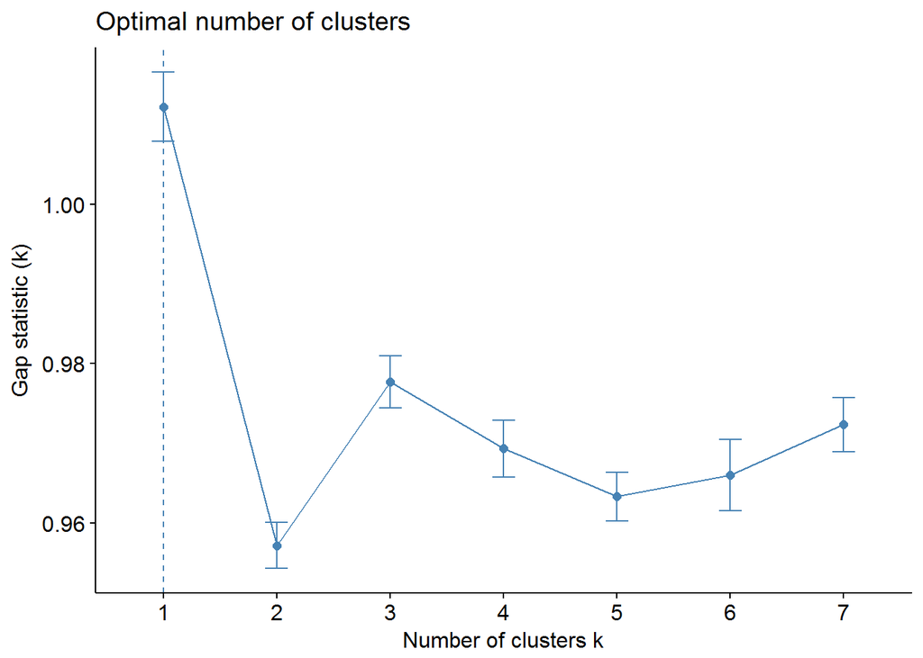

Czy te klastry są podobne? Aby to sprawdzić obliczyliśmy miare podobieństwa Randomized Index, która mówi jakie jest prawdopodobieństwo, że dwie losowo wybrane szkoły będą w tym samym klastrze w obu grupowaniach, lub w różnych klastrach w obu grupowaniach.

```
##        RI
## 0.8013982
```

# Redukcja wymiaru - PCA

Poniższy rysunki przedstawiają procent wyjaśnionej zmienności, podsumowanie PCA oraz autplot, na którym umieszczone są dwa wykresy. Jeden przedstawia indeksy obserwacji przedstawione na układzie współrzędnych określonych przez dwie pierwsze składowe główne (w tym przypadku dwie współrzędne wyjaśniają około 55% całej zmienności). Drugi rysunek przedstawia kierunki w których działają oryginalne zmienne, innymi słowy przedstawiają jak wartość danej zmiennej wpływa na wartości dwóch pierwszych składowych głównych. Jeżeli wektory mają przeciwne zwroty to dane zmienne są ujemnie skorelowane (nie można jednak ocenić wartości korelacji), jeżeli zwroty są prostopadłe to zmienne są nieskorelowane, a jeżeli zwroty są bliskie to zmienne są dodatnio skorelowane. Ponadto kolorami został oznaczony na nim podział na klastry metodą **kmeans**. Z wykresu możemy wyczytać, że statystykami które dobrze odróżniają grupy są, na przykład P13_24_rel (stosunek średniego czasu spędzonego w częściach 1 i 3 do średniego czasu spędzonego we wszystkich częściach), MeanSD_P2, MeanSD_P4 (średnie odchylenia standardowe czasów w części drugiej i czwartej), M2_sr, R2_sr (procentowy udział‚ czasu rozwiązywania zada z matematyki i czytania w części drugiej, w całym czasie rozwiązywania zadń z matematyki i czytania), MeanStudMax_M (średni maksymalny czas rozwiązywania zadania przez studenta danej szkoły).

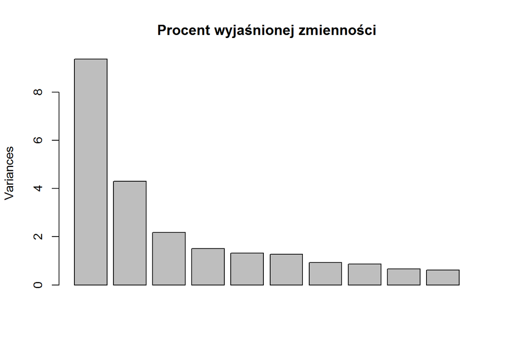

```
## Importance of components:
##                          PC1    PC2    PC3     PC4     PC5     PC6     PC7
## Standard deviation     3.062 2.0747 1.4765 1.22626 1.15193 1.12993 0.96708
## Proportion of Variance 0.375 0.1722 0.0872 0.06015 0.05308 0.05107 0.03741
## Cumulative Proportion  0.375 0.5471 0.6343 0.69449 0.74756 0.79863 0.83604
##                            PC8     PC9   PC10    PC11    PC12    PC13
## Standard deviation     0.93531 0.81588 0.7890 0.73281 0.53224 0.49106
## Proportion of Variance 0.03499 0.02663 0.0249 0.02148 0.01133 0.00965
## Cumulative Proportion  0.87104 0.89766 0.9226 0.94404 0.95538 0.96502
##                           PC14    PC15    PC16    PC17   PC18    PC19
## Standard deviation     0.44592 0.39218 0.37462 0.34185 0.3239 0.27895
## Proportion of Variance 0.00795 0.00615 0.00561 0.00467 0.0042 0.00311
## Cumulative Proportion  0.97298 0.97913 0.98474 0.98942 0.9936 0.99673
##                           PC20    PC21    PC22    PC23      PC24      PC25
## Standard deviation     0.19919 0.13551 0.13003 0.08318 1.519e-15 1.152e-15
## Proportion of Variance 0.00159 0.00073 0.00068 0.00028 0.000e+00 0.000e+00
## Cumulative Proportion  0.99831 0.99905 0.99972 1.00000 1.000e+00 1.000e+00
```

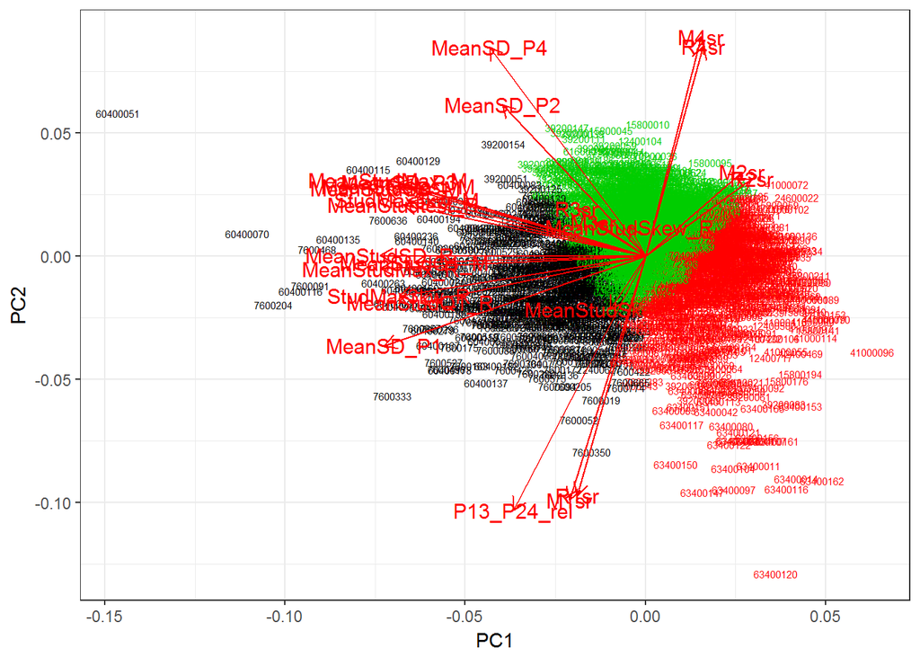

# Analiza wyznaczonych grup

Zaprezentowane wyżej algorytmy pozwoliły na określenie następujących grup:

- **Klepsydra** Jest to grupa szkół, które promowały strategię polegającą na ograniczaniu czasu przeznaczonego na każde zadanie. Możemy wyobrazić sobie, że student takiej szkoły na początku każdego zadania przekręca klepsydrę, a gdy piasek się przesypie, próbuje możliwie szybko zakończyć rozwiązywanie danego zadania. Dzięki temu, studenci tych szkół‚ nie znajdywali się w sytuacji w której nie mieli czasu na rozwiązywanie późniejszych części testu. Studenci tych szkół‚ mieli niskie maksymalne czasy rozwiązywania zadania i niskie odchylenia standardowe czasów rozwiązywania zadań.
- **Po Pół** Szkoły w tej grupie promowały strategię polegającą na równym podziale czasu pomiędzy dwie połowy każdej z dwóch części testu (czyli równy podział‚ czasu rozwiązywania zadań między pozycjami 1 i 2 oraz między pozycjami 3 i 4). Jest to alternatywny sposób dysponowania czasem, który jest trudniejszy w realizacji, ale jednocześnie daje studentowi większą elastyczność.
- **YOLO** - Grupa charakteryzująca się jedną z najbardziej oczywistych strategii, czyli jej brakiem. Członkowie grupy nie potrafią zorganizować czasu, którym dysponują aby rozwiązać test bezstresowo. W pierwszej pozycji testu oraz w trzeciej odznaczają się na tle pozostałych grup najdłuższym łącznym czasem rozwiązywania danej części, natomiast w drugiej i czwartej - najkrótszym. Ponadto ich średnie maksymalne czasy, oraz odchylenia są stosunkowo duże co wskazuje na poświęcanie dużych ilości czasu na zadania, które mogliby pominąć, dzięki czemu mogliby rozwiązać więcej zadań w dalszych częściach testu.

## Uzadadnienie opisów grup

Poniżej znajduje się tabela przedstawiająca procentowy udział średnich łącznych czasów rozwiązywania zadań z każdej pozycji w każdej z grup. Widzimy, że grupa **YOLO** spędziła najmniej czasu na części 2 i 4 oraz najwięcej na 1 i 3. Pamiętając, że między 2, a 3 pozycją odbyła się przerwa dla uczniów wskazuje to na nierozsądne dysponowanie czasem, przez które uczniom zabrakło czasu. **Po Pół** natomiast rozdzieliło swój czas relatywnie równomiernie pomiędzy częściami 1 i 2 oraz pomiędzy częściami 3 i 4. Rozdział‚ czasu pomiędzy częściami w grupie **Klepsydra** jest bardziej równomierny niż w grupie **YOLO**, ale mniej równomierny niż w grupie **Po Pół**.

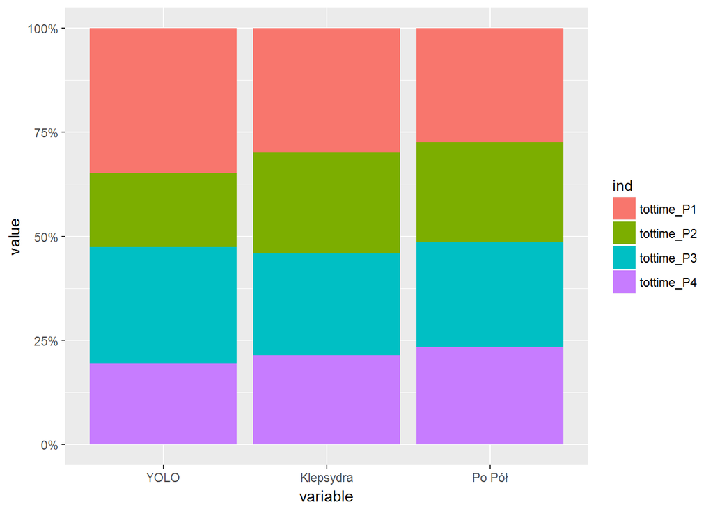

Matematyka i Czytanie

Widzimy na wykresach, że grupa **Klepsydra** ma najniższe średnie odchylenia przy najniższym średnim maksymalnym czasie rozwiazywania zadania. Stąd nasza interpretacja, że członkowie grupy starali się spędzić podobną ilość czasu na każde zadanie, oraz unikać sytuacji w których spędziliby bardzo dużo czasu nad jednym zadaniem, przez co zabrakłoby im czasu na kolejne. Natomiast w **YOLO** występują duże odchylenia standardowe czasów rozwiązywania zadań oraz duże średnie maksymalne czasy rozwiązywania zadań. Stąd nasza interpretacja, że członkowie tej grupy nie dbali o rozsądne zarządzanie czasem. Spędzali na niektórych zadaniach wiele czasu (duże maksymalne czasy) przez co musieli późniejsze zadania rozwiązywać dużo szybciej (duże standardowe odchylenia czasów rozwiązywania).

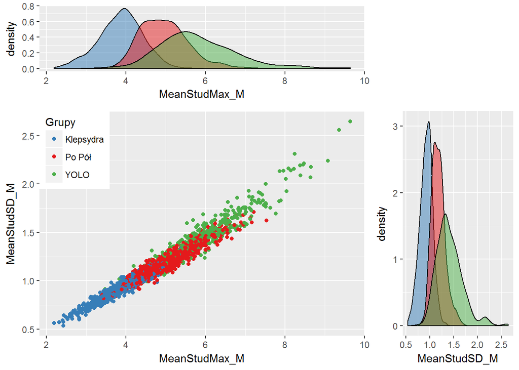

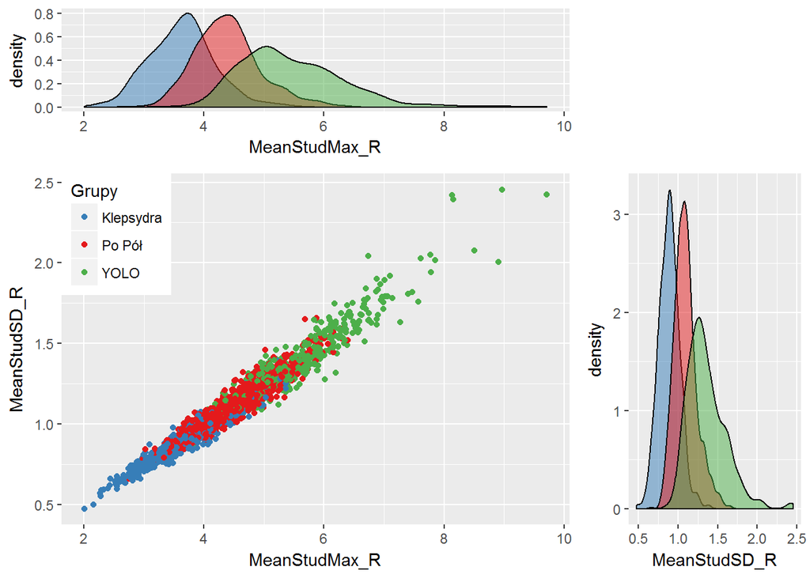

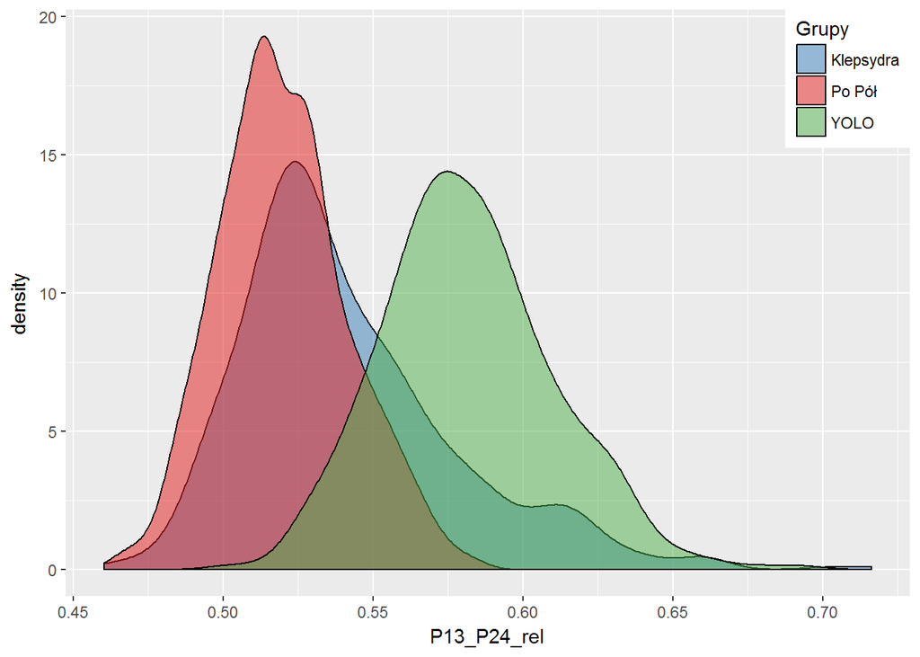

# Wzorce zachowań w krajach

Na wykresie przedstawiamy udział poszczególnych grup na tle wybranych Państw. Widzimy, że zdecydowana większość szkół w Korei stosowała strategie grupy **Klepsydra**, w Katarze było podobnie jednak około 25% stanowiły szkoły wybierające strategie **Po Pół**, a nieznaczna ilość **YOLO**. W Peru i Brazylii dominowały strategie **YOLO**. W Polsce Hiszpanii, Singapurze, Irlandii i Japonii - **Po Pół**.

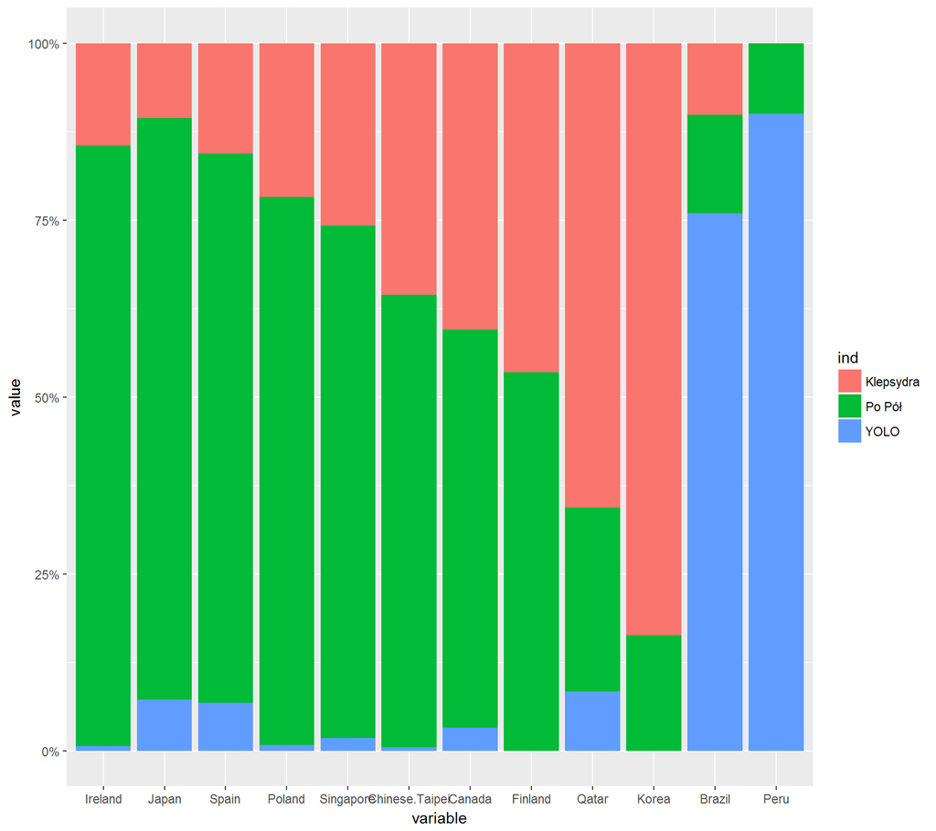

## Wyniki w państwach

Pobraliśmy dane na temat średnich wyników w wybranych krajach oraz procentach uczniów w danych krajach, których wyniki były bardzo dobre lub bardzo słabe. Sprawdziliśmy korelacje między tymi trzema wartościami, a procentowym udziałem grup w krajach. W tabelce przedstawiliśmy otrzymane współczynniki korelacji. Kolorem ciemno-zielonym oznaczyliśmy te korelacje, które były statystycznie istotne( p<0.05, po poprawce Bonferoniego). Dodatkowo jasnym zielonym kolorem zaznaczyliśmy jedną z korelacji, która była blisko wyznaczonego progu istotności.

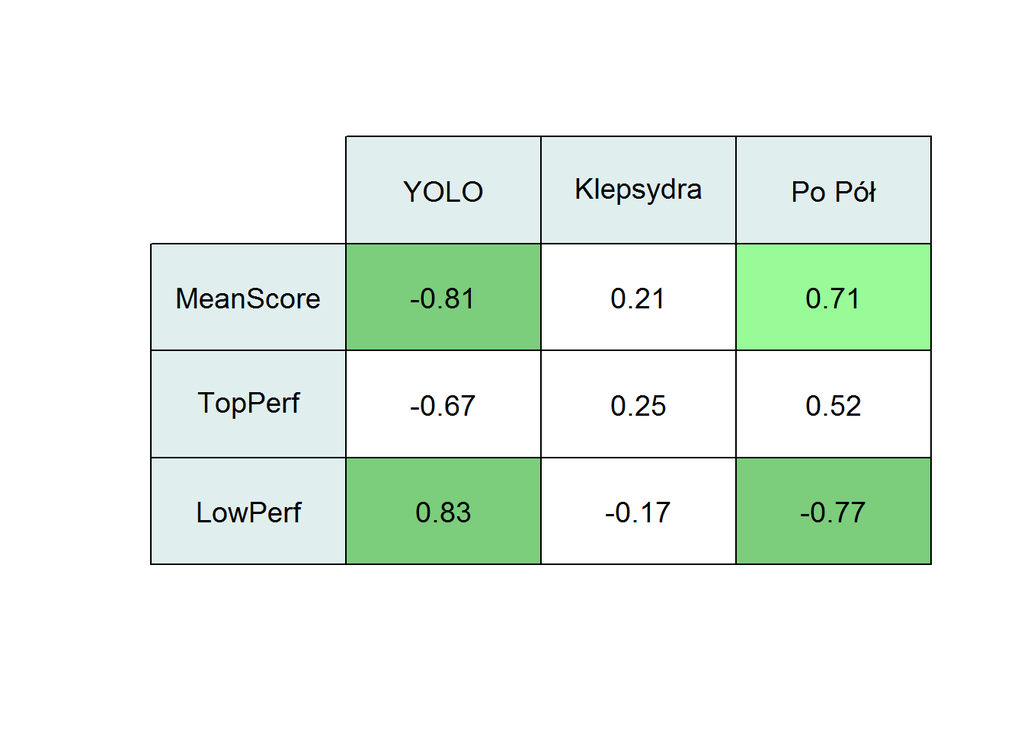

# Podsumowanie

Na podstawie analizy danych wyznaczyliśmy 3 różne grupy szkół odpowiadające trzem różnym sposobom dysponowania czasem podczas pisania testu PISA. Najbardziej efektywną strategią okazała się **Po Pół**, natomiast niewiele gorszą strategią okazała się **Klepsydra**. Naszym zdaniem efektywność strategii **Po Pół** jest wynikiem tego, że nie zmusza studenta do pospiesznego i niedokładnego rozwiązywania zadań w dalszej części testu, jednocześnie dając mu możliwość spędzenia większej ilości czasu na trudniejszych zadaniach. Strategia **Klepsydra** posiada pierwszą z tych zalet jednak brakuje jej elastyczności w organizacji czasu.